# Zróżnicowane funkcjonowanie pozycji testowych (DIF)

Karolina Świst, Tomasz Żółtak

23 września 2016

# 1. Wczytywanie danych

Dane, których będziemy używać w analizach to próba 10 tys. uczniów spośród zdających Sprawdzian w 2005 r. Zbiór danych zostały włączone do pakietu ‘KTT’, o zainstalowanie którego byli Państwo proszeni. Załadowanie tego pakietu spowoduje, że staną się one dostępne, przy czym konieczne jest jeszcze zapunktowanie zadań zamkniętych, których wyniki przechowywane są w postaci informacji o tym, którą odpowiedź wybrał zdający. Oprócz pakietu ‘KTT’ musimy też załadować pakiet ‘mirt’, umożliwiający estymację modeli IRT, w tym analizę zróżnicowanego funkcjonowania pozycji testowych oraz pakiet ‘mvtnorm’ niezbędny do przeliczenia wielkości efektów DIF.

```r
> library(mirt)
Loading required package: stats4
Loading required package: lattice
> library(KTT)
> library(mvtnorm)
>
> daneZapunktowane = przypisz_punktacje(daneSpr2005, opisTestuSpr2005,
+                                       verbose = FALSE)
> parametry_zadan(daneZapunktowane)
Parametry zadań:

test złożony z 37 zadań
10000 obserwacje (zdających)
w macierzy danych nie ma braków danych

rzetelność testu:
alfa Cronbacha  = 0.877
alfa Feldt-Raju = 0.888

 zadanie min. maks. trudność łatwość  MR-P MR-PBZ MR-DS rzetBZ-aC
      Z1    0     1     0.04    0.96 0.277  0.252 0.619 0.876
      Z2    0     1     0.16    0.84 0.518  0.480 0.782 0.873
      Z3    0     1     0.21    0.79 0.462  0.418 0.656 0.874
      Z4    0     1     0.08    0.92 0.441  0.410 0.798 0.874
      Z5    0     1     0.27    0.73 0.455  0.405 0.610 0.874
      Z6    0     1     0.45    0.55 0.397  0.338 0.499 0.875
      Z7    0     1     0.14    0.86 0.379  0.337 0.585 0.875
      Z8    0     1     0.11    0.89 0.336  0.297 0.554 0.876
      Z9    0     1     0.08    0.92 0.346  0.313 0.630 0.876
     Z10    0     1     0.23    0.77 0.368  0.317 0.512 0.875
     Z11    0     1     0.28    0.72 0.471  0.422 0.629 0.873
     Z12    0     1     0.19    0.81 0.314  0.265 0.456 0.876
     Z13    0     1     0.17    0.83 0.415  0.371 0.619 0.874
     Z14    0     1     0.41    0.59 0.256  0.192 0.324 0.878 (!)
     Z15    0     1     0.26    0.74 0.404  0.352 0.546 0.875
     Z16    0     1     0.05    0.95 0.353  0.328 0.767 0.876
     Z17    0     1     0.05    0.95 0.289  0.262 0.620 0.876
     Z18    0     1     0.36    0.64 0.339  0.280 0.436 0.876
     Z19    0     1     0.11    0.89 0.428  0.393 0.711 0.874
     Z20    0     1     0.26    0.74 0.364  0.311 0.494 0.875
   Z21_1    0     2     0.30    0.70 0.730  0.670    NA 0.866
   Z21_2    0     2     0.45    0.55 0.719  0.654    NA 0.867
   Z21_3    0     1     0.38    0.62 0.692  0.656 0.882 0.868
     Z22    0     1     0.19    0.81 0.303  0.254 0.441 0.876
   Z23_1    0     1     0.31    0.69 0.358  0.301 0.470 0.876
   Z23_2    0     1     0.04    0.96 0.210  0.184 0.480 0.877
   Z23_3    0     1     0.57    0.43 0.376  0.316 0.474 0.876
   Z23_4    0     1     0.39    0.61 0.363  0.304 0.462 0.876
   Z23_5    0     1     0.43    0.57 0.388  0.328 0.489 0.875
     Z24    0     1     0.12    0.88 0.264  0.222 0.428 0.877
   Z25_1    0     1     0.13    0.87 0.567  0.534 0.898 0.872
   Z25_2    0     1     0.26    0.74 0.595  0.554 0.804 0.871
   Z25_3    0     1     0.26    0.74 0.612  0.573 0.828 0.871
   Z25_4    0     1     0.62    0.38 0.454  0.399 0.578 0.874
   Z25_5    0     1     0.34    0.66 0.579  0.534 0.750 0.871
   Z25_6    0     1     0.32    0.68 0.546  0.500 0.712 0.872
     Z26    0     2     0.40    0.60 0.537  0.432    NA 0.877
 rzetBZ-aFR
  0.887
  0.884
  0.885
  0.886
  0.885
  0.887
  0.886
  0.887
  0.887
  0.887
  0.885
  0.887
  0.886
  0.889 (!)
  0.886
  0.887
  0.887
  0.888
  0.886
  0.887
  0.875
  0.876
  0.879
  0.888
  0.887
  0.888
  0.887
  0.887
  0.887
  0.888
  0.884
  0.883
  0.882
  0.886
  0.883
  0.884
  0.888

min.       - minimalna liczba punktów możliwych do uzyskania za zadanie
maks.      - maksymalna liczba punktów możliwych do uzyskania za zadanie
MR-P       - moc różnicująca: korelacja liniowa Pearsona (punktowo-dwuseryjna)
MR-PBZ     - moc różnicująca: korelacja Pearsona z sumą punktów z wyłączeniem danego zadania
MR-DS      - moc różnicująca: korelacja dwuseryjna
rzetBZ-aC  - rzetelność bez zadania: alfa Cronbacha
rzetBZ-aFR - rzetelność bez zadania: alfa Feldt-Raju
Zadania, po usunięciu których rzetelność rośnie oznaczono '(!)'
```

Przy okazji porównajmy parametry dla wyniku sumarycznego w grupie chłopców i dziewcząt

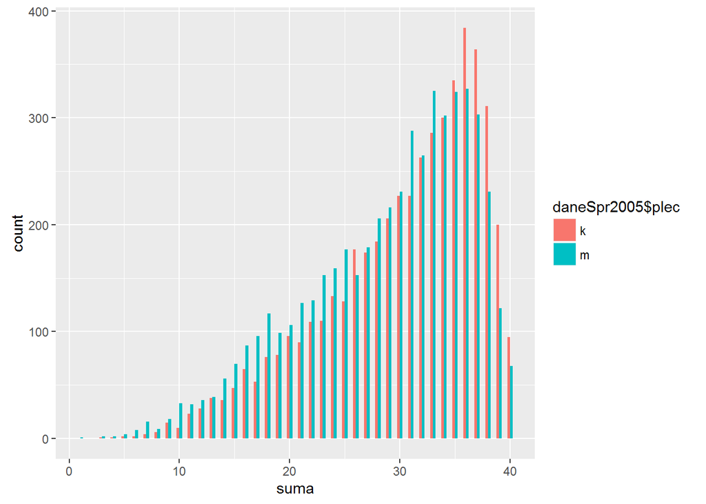

```r
> library(psych)
> library(ggplot2)

Attaching package: 'ggplot2'
The following objects are masked from 'package:psych':

    %+%, alpha
> daneZapunktowane$suma = rowSums(daneZapunktowane)
> describeBy(daneZapunktowane$suma, daneSpr2005$plec)
group: k
   vars    n  mean  sd median trimmed  mad min max range  skew kurtosis
X1    1 4884 30.16 7.1     32   30.94 7.41   3  40    37 -0.87     0.12
    se
X1 0.1
--------------------------------------------------------
group: m
   vars    n  mean   sd median trimmed  mad min max range  skew kurtosis
X1    1 5116 28.74 7.54     30   29.43 7.41   1  40    39 -0.74    -0.17
     se
X1 0.11
> ggplot(daneZapunktowane, aes(x=suma, fill = daneSpr2005$plec)) + geom_histogram(binwidth=0.5, position = "dodge")
```

ĆWICZENIE 1: Co można (wstępnie) powiedzieć o surowych wynikach chłopców i dziewcząt ze sprawdzianu 2005? # 2. Estymacja modeli (najpierw wyrzucimy sumę punktów z naszych danych)

```r
> daneZapunktowane$suma = NULL
```

Aby zbadać, czy zachodzi zróżnicowane funkcjonowanie zadań ze względu na płeć, musimy wyestymować model zakładający pełną inwariancję oraz modele, dopuszczające takie zróżnicowanie (różne jego formy), a następnie je ze sobą porównać. Odpowiedzi na zadania będziemy modelować modelem 2PL w przypadku zadań ocenianych binarnie i GPCM dla zadań o większej liczbie poziomów wykonania.

Do estymacji modeli wielogrupowych, umożliwiających badanie DIF będziemy używać funkcji **multipleGroup** z pakietu ‘mirt’ (domyślnie zakłada ona model 2PL/GPCM, choć w razie potrzeby można to zmienić).

```r
multipleGroup(dane, opis_modelu, group = wektor_opisujacy_przydzial_do_grup,
              invariance = wektor_tekstowy_opisujacy_roznice_miedzy_grupami)
```

Domyślnie (gdy nie został podany argument ‘invariance’) estymowany jest model, w którym zakłada się taki sam rozkład mierzonej cechy we wszytkich grupach, ale dopuszcza się zróżnicowanie parametrów zadań pomiędzy grupami. Jeśli chcemy to zmienić, możemy zawrzeć w wektorze przekazywanym jako argument ‘invariance’ następujące ciągi znaków:

- ‘slopes’ - nakłada założenie o równości parametrów dyskryminacji pomiędzy grupami;
- ‘intercepts’ - nakłada założenie o równości parametrów trudności pomiędzy grupami;
- ‘free_means’ - uwalnia średnie pomiędzy modelami;
- ‘free_var’ - uwalnia parametry wariancji pomiędzy grupami.

Spośród estymowanych poniżej modeli:

- **mg_constrained** zakłada pełną inwariancję pomiarową;
- **mg_metric** zakłada inwariancję metryczną (równe parametry dyskryminacji);
- ** mg_scalar1** zakłada inwariancję skalarną (równe parametry dyskryminacji i trudności) z uwolnionymi wariancjami
- ** mg_scalar2** zakłada inwariancję skalarną (rowne parametry dyskryminacji i trudności) z uwolnionymi średnimi i wariancjami
- **mg_metric** zakłada inwariancję metryczną (równe parametry dyskryminacji);
- **mg_configural** zakłada inwariancję konfiguralną (uwolnione parametry dyskryminacji i trudności)
- **mg_configural_fg** dopuszcza zarówno zróżnicowanie parametrow zadań pomiędzy grupami, jak też uwalnia parametry rozkładu mierzonej cechy w grupie ogniskowej; w ogólności nie jest to dobry model - czasem (w przypadku niektórych zbiorów danych) może nie dać się go wyestymować (o czym zostaniemy ostrzeżeni przy wywoływaniu funkcji ‘multipleGroup’), ale bywa użyteczny do oceny DIF;

```r
> plec = daneSpr2005$plec
>
> m = mirt(daneZapunktowane, 1)
```

```
Iteration: 1, Log-Lik: -173506.511, Max-Change: 1.82266
Iteration: 2, Log-Lik: -170278.313, Max-Change: 1.16768
Iteration: 3, Log-Lik: -169170.431, Max-Change: 0.67451
Iteration: 4, Log-Lik: -168853.309, Max-Change: 0.54538
Iteration: 5, Log-Lik: -168609.050, Max-Change: 0.38943
Iteration: 6, Log-Lik: -168501.347, Max-Change: 0.34223
Iteration: 7, Log-Lik: -168440.536, Max-Change: 0.30060
Iteration: 8, Log-Lik: -168400.987, Max-Change: 0.27377
Iteration: 9, Log-Lik: -168378.910, Max-Change: 0.25036
Iteration: 10, Log-Lik: -168358.276, Max-Change: 0.23264
Iteration: 11, Log-Lik: -168348.751, Max-Change: 0.19903
Iteration: 12, Log-Lik: -168340.126, Max-Change: 0.20693
Iteration: 13, Log-Lik: -168332.713, Max-Change: 0.19271
Iteration: 14, Log-Lik: -168327.124, Max-Change: 0.17870
Iteration: 15, Log-Lik: -168322.078, Max-Change: 0.16702
Iteration: 16, Log-Lik: -168318.523, Max-Change: 0.15642
Iteration: 17, Log-Lik: -168314.962, Max-Change: 0.16432
Iteration: 18, Log-Lik: -168311.328, Max-Change: 0.15430
Iteration: 19, Log-Lik: -168305.725, Max-Change: 0.11392
Iteration: 20, Log-Lik: -168301.686, Max-Change: 0.10839
Iteration: 21, Log-Lik: -168300.434, Max-Change: 0.10935
Iteration: 22, Log-Lik: -168297.084, Max-Change: 0.09414
Iteration: 23, Log-Lik: -168295.983, Max-Change: 0.09106
Iteration: 24, Log-Lik: -168295.476, Max-Change: 0.06720
Iteration: 25, Log-Lik: -168294.633, Max-Change: 0.11077
Iteration: 26, Log-Lik: -168294.247, Max-Change: 0.00007
```

```r
> mg_constrained = multipleGroup(daneZapunktowane, 1, group = plec,
+                                invariance = c('slopes', 'intercepts'))
```

```
Iteration: 1, Log-Lik: -173506.511, Max-Change: 1.82266
Iteration: 2, Log-Lik: -170278.313, Max-Change: 1.16768
Iteration: 3, Log-Lik: -169170.431, Max-Change: 0.67451
Iteration: 4, Log-Lik: -168853.309, Max-Change: 0.54538
Iteration: 5, Log-Lik: -168609.050, Max-Change: 0.38943
Iteration: 6, Log-Lik: -168501.347, Max-Change: 0.34223
Iteration: 7, Log-Lik: -168440.536, Max-Change: 0.30060
Iteration: 8, Log-Lik: -168400.987, Max-Change: 0.27377
Iteration: 9, Log-Lik: -168378.910, Max-Change: 0.25036
Iteration: 10, Log-Lik: -168358.276, Max-Change: 0.23264
Iteration: 11, Log-Lik: -168348.751, Max-Change: 0.19903
Iteration: 12, Log-Lik: -168340.126, Max-Change: 0.20693
Iteration: 13, Log-Lik: -168332.713, Max-Change: 0.19271
Iteration: 14, Log-Lik: -168327.124, Max-Change: 0.17870
Iteration: 15, Log-Lik: -168322.078, Max-Change: 0.16702
Iteration: 16, Log-Lik: -168318.523, Max-Change: 0.15642
Iteration: 17, Log-Lik: -168314.962, Max-Change: 0.16432
Iteration: 18, Log-Lik: -168311.328, Max-Change: 0.15430
Iteration: 19, Log-Lik: -168305.725, Max-Change: 0.11392
Iteration: 20, Log-Lik: -168301.686, Max-Change: 0.10839
Iteration: 21, Log-Lik: -168300.434, Max-Change: 0.10935
Iteration: 22, Log-Lik: -168297.084, Max-Change: 0.09414
Iteration: 23, Log-Lik: -168295.983, Max-Change: 0.09106
Iteration: 24, Log-Lik: -168295.475, Max-Change: 0.06724
Iteration: 25, Log-Lik: -168294.631, Max-Change: 0.11095
Iteration: 26, Log-Lik: -168294.244, Max-Change: 0.00007
```

```r
> mg_metric = multipleGroup(daneZapunktowane, 1, group = plec,
+                           invariance = c('slopes'))
```

```
Iteration: 1, Log-Lik: -173506.511, Max-Change: 3.13224
Iteration: 2, Log-Lik: -171076.550, Max-Change: 2.74989
Iteration: 3, Log-Lik: -170012.851, Max-Change: 1.08336
Iteration: 4, Log-Lik: -169007.273, Max-Change: 0.66577
Iteration: 5, Log-Lik: -168562.927, Max-Change: 0.44397
Iteration: 6, Log-Lik: -168198.729, Max-Change: 0.41440
Iteration: 7, Log-Lik: -167896.168, Max-Change: 0.39949
Iteration: 8, Log-Lik: -167785.112, Max-Change: 0.31168
Iteration: 9, Log-Lik: -167717.396, Max-Change: 0.28734
Iteration: 10, Log-Lik: -167663.387, Max-Change: 0.28682
Iteration: 11, Log-Lik: -167641.443, Max-Change: 0.24103
Iteration: 12, Log-Lik: -167609.201, Max-Change: 0.22176
Iteration: 13, Log-Lik: -167595.397, Max-Change: 0.20031
Iteration: 14, Log-Lik: -167583.880, Max-Change: 0.18580
Iteration: 15, Log-Lik: -167570.224, Max-Change: 0.17543
Iteration: 16, Log-Lik: -167561.460, Max-Change: 0.19397
Iteration: 17, Log-Lik: -167550.217, Max-Change: 0.15351
Iteration: 18, Log-Lik: -167546.157, Max-Change: 0.14596
Iteration: 19, Log-Lik: -167535.170, Max-Change: 0.13568
Iteration: 20, Log-Lik: -167524.624, Max-Change: 0.10587
Iteration: 21, Log-Lik: -167522.543, Max-Change: 0.09742
Iteration: 22, Log-Lik: -167522.358, Max-Change: 0.09098
Iteration: 23, Log-Lik: -167515.007, Max-Change: 0.00283
Iteration: 24, Log-Lik: -167514.999, Max-Change: 0.07708
Iteration: 25, Log-Lik: -167514.431, Max-Change: 0.07324
Iteration: 26, Log-Lik: -167514.003, Max-Change: 0.00597
Iteration: 27, Log-Lik: -167513.917, Max-Change: 0.00149
Iteration: 28, Log-Lik: -167513.906, Max-Change: 0.07480
Iteration: 29, Log-Lik: -167513.524, Max-Change: 0.06870
Iteration: 30, Log-Lik: -167513.226, Max-Change: 0.06541
Iteration: 31, Log-Lik: -167511.935, Max-Change: 0.04627
Iteration: 32, Log-Lik: -167511.684, Max-Change: 0.00021
Iteration: 33, Log-Lik: -167511.682, Max-Change: 0.00008
```

```r
> mg_configural = multipleGroup(daneZapunktowane, 1, group = plec)
```

```
Iteration: 1, Log-Lik: -173506.511, Max-Change: 2.37583
Iteration: 2, Log-Lik: -170645.366, Max-Change: 0.89336
Iteration: 3, Log-Lik: -168536.990, Max-Change: 0.77069
Iteration: 4, Log-Lik: -168059.623, Max-Change: 0.46423
Iteration: 5, Log-Lik: -167824.144, Max-Change: 0.25277
Iteration: 6, Log-Lik: -167753.332, Max-Change: 0.32638
Iteration: 7, Log-Lik: -167670.047, Max-Change: 0.23933
Iteration: 8, Log-Lik: -167635.764, Max-Change: 0.29792
Iteration: 9, Log-Lik: -167595.230, Max-Change: 0.18625
Iteration: 10, Log-Lik: -167575.571, Max-Change: 0.17247
Iteration: 11, Log-Lik: -167559.989, Max-Change: 0.17531
Iteration: 12, Log-Lik: -167545.192, Max-Change: 0.15220
Iteration: 13, Log-Lik: -167536.332, Max-Change: 0.16431
Iteration: 14, Log-Lik: -167526.443, Max-Change: 0.15139
Iteration: 15, Log-Lik: -167519.460, Max-Change: 0.14359
Iteration: 16, Log-Lik: -167514.070, Max-Change: 0.11507
Iteration: 17, Log-Lik: -167510.439, Max-Change: 0.12467
Iteration: 18, Log-Lik: -167506.103, Max-Change: 0.11300
Iteration: 19, Log-Lik: -167498.801, Max-Change: 0.10019
Iteration: 20, Log-Lik: -167495.368, Max-Change: 0.08323
Iteration: 21, Log-Lik: -167492.638, Max-Change: 0.09054
Iteration: 22, Log-Lik: -167486.226, Max-Change: 0.18519
Iteration: 23, Log-Lik: -167484.031, Max-Change: 0.08465
Iteration: 24, Log-Lik: -167482.779, Max-Change: 0.08208
Iteration: 25, Log-Lik: -167481.214, Max-Change: 0.13401
Iteration: 26, Log-Lik: -167480.277, Max-Change: 0.08502
Iteration: 27, Log-Lik: -167479.752, Max-Change: 0.05579
Iteration: 28, Log-Lik: -167479.203, Max-Change: 0.09108
Iteration: 29, Log-Lik: -167478.535, Max-Change: 0.00010
Iteration: 30, Log-Lik: -167478.534, Max-Change: 0.00020
Iteration: 31, Log-Lik: -167478.532, Max-Change: 0.05205
Iteration: 32, Log-Lik: -167478.214, Max-Change: 0.00032
Iteration: 33, Log-Lik: -167478.213, Max-Change: 0.00008
```

```r
> mg_configural_fg = multipleGroup(daneZapunktowane, 1, group = plec,
+                                  invariance = c('free_var', 'free_means'))
```

```
Iteration: 1, Log-Lik: -173506.511, Max-Change: 1.62446
Iteration: 2, Log-Lik: -169419.554, Max-Change: 0.90242
Iteration: 3, Log-Lik: -167904.656, Max-Change: 0.39618
Iteration: 4, Log-Lik: -167745.052, Max-Change: 0.36956
Iteration: 5, Log-Lik: -167656.193, Max-Change: 0.31323
Iteration: 6, Log-Lik: -167614.244, Max-Change: 0.24794
Iteration: 7, Log-Lik: -167577.797, Max-Change: 0.24464
Iteration: 8, Log-Lik: -167555.547, Max-Change: 0.19052
Iteration: 9, Log-Lik: -167542.566, Max-Change: 0.16441
Iteration: 10, Log-Lik: -167533.917, Max-Change: 0.17509
Iteration: 11, Log-Lik: -167522.484, Max-Change: 0.15855
Iteration: 12, Log-Lik: -167515.829, Max-Change: 0.13891
Iteration: 13, Log-Lik: -167511.260, Max-Change: 0.07192
Iteration: 14, Log-Lik: -167507.242, Max-Change: 0.14892
Iteration: 15, Log-Lik: -167503.358, Max-Change: 0.12562
Iteration: 16, Log-Lik: -167492.556, Max-Change: 0.08905
Iteration: 17, Log-Lik: -167489.911, Max-Change: 0.09776
Iteration: 18, Log-Lik: -167488.189, Max-Change: 0.09551
Iteration: 19, Log-Lik: -167482.359, Max-Change: 0.08707
Iteration: 20, Log-Lik: -167480.703, Max-Change: 0.01129
Iteration: 21, Log-Lik: -167480.464, Max-Change: 0.00167
Iteration: 22, Log-Lik: -167480.459, Max-Change: 0.00070
Iteration: 23, Log-Lik: -167480.456, Max-Change: 0.00022
Iteration: 24, Log-Lik: -167480.455, Max-Change: 0.00094
Iteration: 25, Log-Lik: -167480.451, Max-Change: 0.00026
Iteration: 26, Log-Lik: -167480.451, Max-Change: 0.00006
```

```r
> mg_scalar1 = multipleGroup(daneZapunktowane, 1, group = plec,
+                            invariance = c('slopes', 'intercepts',
+                                           'free_var'))
```

```
Iteration: 1, Log-Lik: -173506.511, Max-Change: 2.04628
Iteration: 2, Log-Lik: -170107.512, Max-Change: 1.42803
Iteration: 3, Log-Lik: -169322.632, Max-Change: 0.69691
Iteration: 4, Log-Lik: -168889.360, Max-Change: 0.42577
Iteration: 5, Log-Lik: -168724.008, Max-Change: 0.18097
Iteration: 6, Log-Lik: -168644.075, Max-Change: 0.23120
Iteration: 7, Log-Lik: -168570.536, Max-Change: 0.19872
Iteration: 8, Log-Lik: -168516.565, Max-Change: 0.37611
Iteration: 9, Log-Lik: -168481.967, Max-Change: 0.33065
Iteration: 10, Log-Lik: -168438.977, Max-Change: 0.31749
Iteration: 11, Log-Lik: -168419.497, Max-Change: 0.24036
Iteration: 12, Log-Lik: -168402.091, Max-Change: 0.25705
Iteration: 13, Log-Lik: -168382.551, Max-Change: 0.24728
Iteration: 14, Log-Lik: -168371.002, Max-Change: 0.21130
Iteration: 15, Log-Lik: -168358.663, Max-Change: 0.22269
Iteration: 16, Log-Lik: -168351.059, Max-Change: 0.17623
Iteration: 17, Log-Lik: -168344.662, Max-Change: 0.15018
Iteration: 18, Log-Lik: -168338.652, Max-Change: 0.16417
Iteration: 19, Log-Lik: -168333.707, Max-Change: 0.14840
Iteration: 20, Log-Lik: -168329.303, Max-Change: 0.15030
Iteration: 21, Log-Lik: -168325.533, Max-Change: 0.13547
Iteration: 22, Log-Lik: -168316.806, Max-Change: 0.15743
Iteration: 23, Log-Lik: -168310.221, Max-Change: 0.10621
Iteration: 24, Log-Lik: -168307.939, Max-Change: 0.11040
Iteration: 25, Log-Lik: -168303.273, Max-Change: 0.08075
Iteration: 26, Log-Lik: -168301.988, Max-Change: 0.09455
Iteration: 27, Log-Lik: -168301.020, Max-Change: 0.00550
Iteration: 28, Log-Lik: -168300.957, Max-Change: 0.08743
Iteration: 29, Log-Lik: -168300.024, Max-Change: 0.00459
Iteration: 30, Log-Lik: -168299.786, Max-Change: 0.09067
Iteration: 31, Log-Lik: -168299.183, Max-Change: 0.00387
Iteration: 32, Log-Lik: -168298.902, Max-Change: 0.08789
Iteration: 33, Log-Lik: -168298.197, Max-Change: 0.00346
Iteration: 34, Log-Lik: -168298.164, Max-Change: 0.00313
Iteration: 35, Log-Lik: -168297.977, Max-Change: 0.08479
Iteration: 36, Log-Lik: -168297.474, Max-Change: 0.00870
Iteration: 37, Log-Lik: -168297.382, Max-Change: 0.00898
Iteration: 38, Log-Lik: -168297.123, Max-Change: 0.00191
Iteration: 39, Log-Lik: -168296.924, Max-Change: 0.08619
Iteration: 40, Log-Lik: -168296.481, Max-Change: 0.00762
```

[output cut: 28 more lines]

```
Iteration: 69, Log-Lik: -168293.074, Max-Change: 0.00104
Iteration: 70, Log-Lik: -168293.043, Max-Change: 0.00557
Iteration: 71, Log-Lik: -168293.004, Max-Change: 0.00086
Iteration: 72, Log-Lik: -168292.980, Max-Change: 0.00112
Iteration: 73, Log-Lik: -168292.920, Max-Change: 0.00539
Iteration: 74, Log-Lik: -168292.865, Max-Change: 0.00101
Iteration: 75, Log-Lik: -168292.847, Max-Change: 0.00077
Iteration: 76, Log-Lik: -168292.842, Max-Change: 0.00051
Iteration: 77, Log-Lik: -168292.826, Max-Change: 0.00034
Iteration: 78, Log-Lik: -168292.825, Max-Change: 0.00010
Iteration: 79, Log-Lik: -168292.825, Max-Change: 0.00015
Iteration: 80, Log-Lik: -168292.823, Max-Change: 0.00021
Iteration: 81, Log-Lik: -168292.821, Max-Change: 0.00015
Iteration: 82, Log-Lik: -168292.821, Max-Change: 0.00022
Iteration: 83, Log-Lik: -168292.819, Max-Change: 0.00008
```

```r
> mg_scalar2 = multipleGroup(daneZapunktowane, 1, group = plec,
+                            invariance = c('slopes', 'intercepts',
+                                           'free_var', 'free_means'))
```

```
Iteration: 1, Log-Lik: -173506.511, Max-Change: 2.04090
Iteration: 2, Log-Lik: -170077.966, Max-Change: 1.24025
Iteration: 3, Log-Lik: -169195.470, Max-Change: 0.59752
Iteration: 4, Log-Lik: -168802.446, Max-Change: 0.29615
Iteration: 5, Log-Lik: -168652.683, Max-Change: 0.35269
Iteration: 6, Log-Lik: -168555.774, Max-Change: 0.44771
Iteration: 7, Log-Lik: -168451.017, Max-Change: 0.27855
Iteration: 8, Log-Lik: -168411.145, Max-Change: 0.31497
Iteration: 9, Log-Lik: -168367.302, Max-Change: 0.31125
Iteration: 10, Log-Lik: -168343.833, Max-Change: 0.24788
Iteration: 11, Log-Lik: -168325.593, Max-Change: 0.18669
Iteration: 12, Log-Lik: -168311.272, Max-Change: 0.25538
Iteration: 13, Log-Lik: -168298.534, Max-Change: 0.20314
Iteration: 14, Log-Lik: -168290.102, Max-Change: 0.17395
Iteration: 15, Log-Lik: -168282.545, Max-Change: 0.19508
Iteration: 16, Log-Lik: -168276.753, Max-Change: 0.16905
Iteration: 17, Log-Lik: -168271.747, Max-Change: 0.17492
Iteration: 18, Log-Lik: -168268.414, Max-Change: 0.18178
Iteration: 19, Log-Lik: -168263.698, Max-Change: 0.17340
Iteration: 20, Log-Lik: -168254.670, Max-Change: 0.17678
Iteration: 21, Log-Lik: -168252.047, Max-Change: 0.00662
Iteration: 22, Log-Lik: -168251.963, Max-Change: 0.00359
Iteration: 23, Log-Lik: -168251.938, Max-Change: 0.00656
Iteration: 24, Log-Lik: -168251.700, Max-Change: 0.13513
Iteration: 25, Log-Lik: -168250.516, Max-Change: 0.11917
Iteration: 26, Log-Lik: -168249.607, Max-Change: 0.10828
Iteration: 27, Log-Lik: -168248.814, Max-Change: 0.00284
Iteration: 28, Log-Lik: -168248.795, Max-Change: 0.00192
Iteration: 29, Log-Lik: -168248.786, Max-Change: 0.00014
Iteration: 30, Log-Lik: -168248.785, Max-Change: 0.00039
Iteration: 31, Log-Lik: -168248.782, Max-Change: 0.00009
```

# 3. Porównanie modeli między sobą

## Porównanie dopasowania modeli do danych

```r
> # porownujemy ze soba (modele zagniezdzone)
> anova(mg_constrained, mg_metric)

Model 1: multipleGroup(data = daneZapunktowane, model = 1, group = plec,
    invariance = c("slopes", "intercepts"))
Model 2: multipleGroup(data = daneZapunktowane, model = 1, group = plec,
    invariance = c("slopes"))
       AIC     AICc    SABIC      BIC    logLik       X2  df   p
1 336742.5 336743.7 337053.0 337297.7 -168294.2      NaN NaN NaN
2 335257.4 335260.2 335729.2 336101.0 -167511.7 1565.124  40   0
>
> anova(mg_metric, mg_configural)

Model 1: multipleGroup(data = daneZapunktowane, model = 1, group = plec,
    invariance = c("slopes"))
Model 2: multipleGroup(data = daneZapunktowane, model = 1, group = plec)
       AIC     AICc    SABIC      BIC    logLik     X2  df      p
1 335257.4 335260.2 335729.2 336101.0 -167511.7    NaN NaN    NaN
2 335264.4 335269.3 335885.4 336374.8 -167478.2 66.939  37 0.0019
>
> # mozna przetestowac tez dalsze hipotezy, choc w naszym wypadku widac juz,
> # ze mamy do czynienia z DIF niejednorodnym
> #anova(mg_scalar2, mg_metric)
> #anova(mg_scalar1, mg_scalar2)
> #anova(mg_constrained, mg_scalar1)
```

## Ostrzeżenie!

**Uwaga, modeli wyestymowanych funkcją ‘mirt’ i funkcją ‘multipleGroup’ nie należy ze sobą porównywać funkcją ‘anova’**. Dwa poniższe modele są tożsame, co widać po wartościach statystyk AIC, BIC itp., ale implementacja testu chi-kwadrat daje w tej sytuacji bzdurne rezultaty:

```r
> anova(m, mg_constrained)

Model 1: mirt(data = daneZapunktowane, model = 1)
Model 2: multipleGroup(data = daneZapunktowane, model = 1, group = plec,
    invariance = c("slopes", "intercepts"))
       AIC     AICc  SABIC      BIC    logLik    X2  df   p
1 336742.5 336743.7 337053 337297.7 -168294.2   NaN NaN NaN
2 336742.5 336743.7 337053 337297.7 -168294.2 0.005   0   0
```

## Różnice w parametrach rozkładu mierzonej cechy

```
Model zakładający inwariancję zadań,
ale uwalniający parametry rozkładu cechy:
       k      m
MEAN_1 0 -0.215
COV_11 1  1.007
Model uwalniający wszystkie parametry:
       k      m
MEAN_1 0 -0.095
COV_11 1  1.729
```

ĆWICZENIE 2: Co można powiedzieć o parametrach rozkładu umiejętności chłopców i dziewcząt ze sprawdzianu 2005?

# 4. Analiza graficzna

Wskazówek na temat tego, które zadania łamią założenie inwariancji pomiarowej może dostarczyć graficzna analiza różnic w przebiegu funkcji charakterystycznych zadań pomiędzy grupami. Poniżej wykresy dla pierwszych 10 zadań z modelu dopuszczającego zróżnicowania zarówno trudności, jak i dyskryminacji zadań.

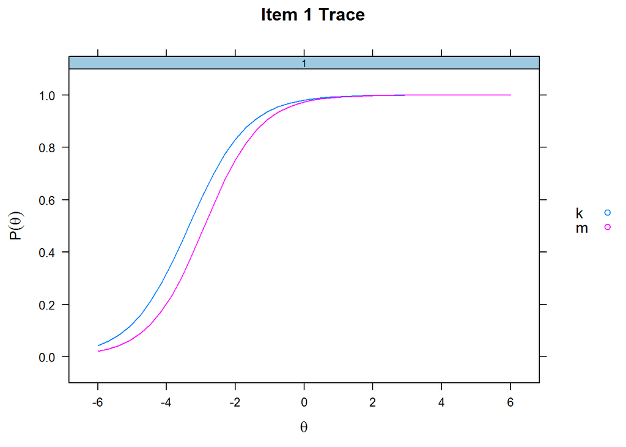

```r
> itemplot(mg_configural, item = 1)
```

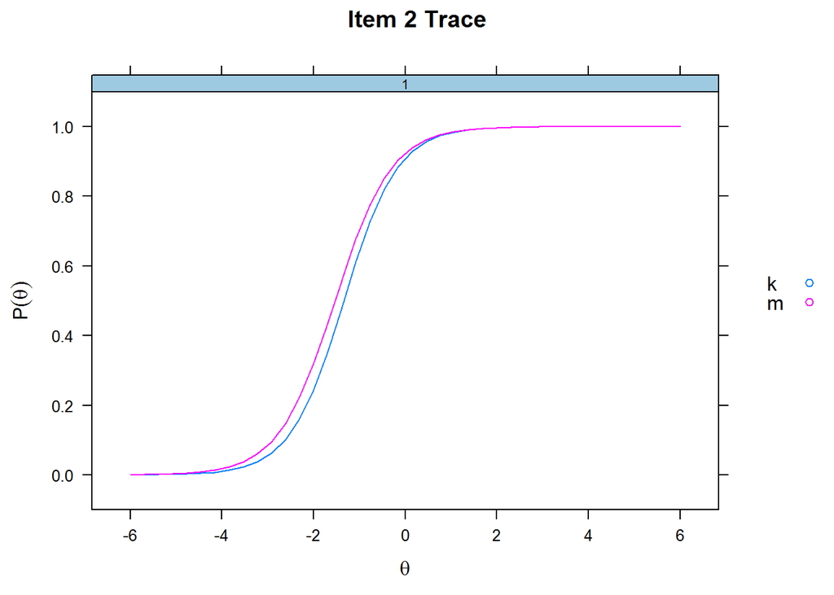

```r
> itemplot(mg_configural, item = 2)
```

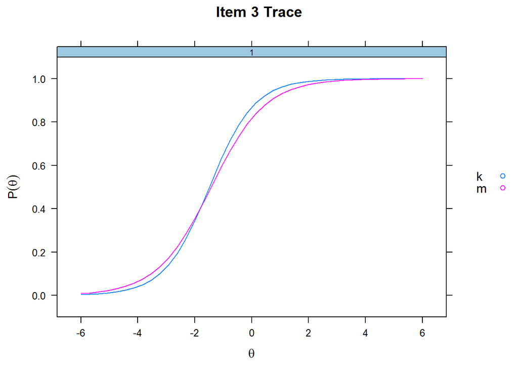

```r
> itemplot(mg_configural, item = 3)
```

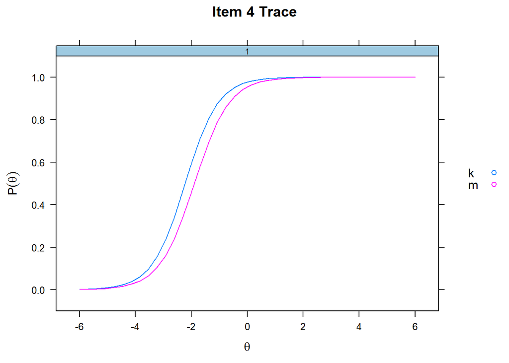

```r
> itemplot(mg_configural, item = 4)
```

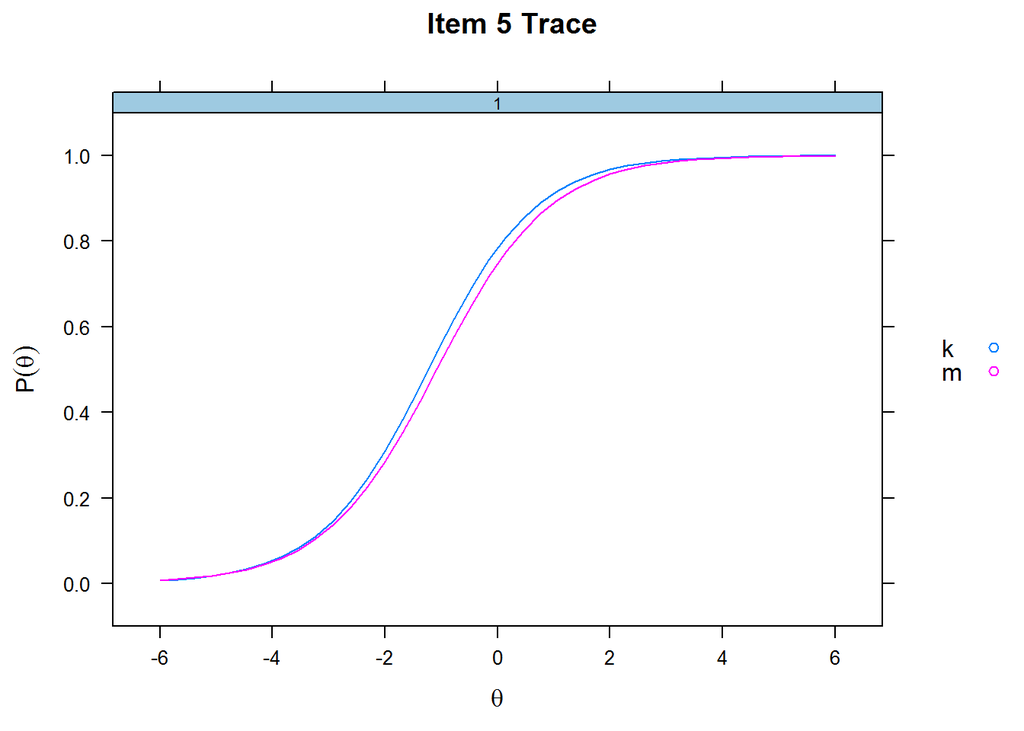

```r
> itemplot(mg_configural, item = 5)
```

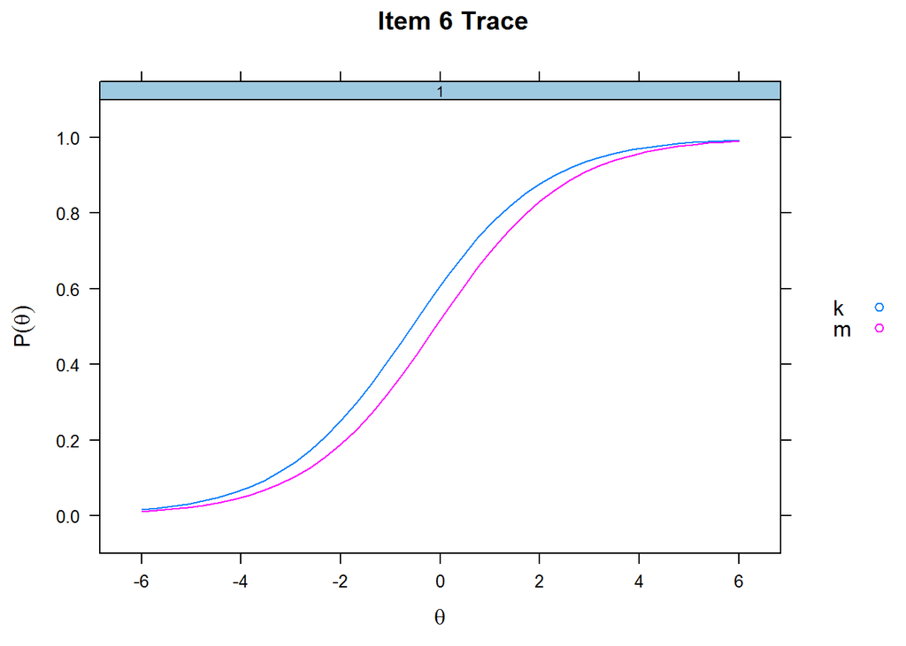

```r
> itemplot(mg_configural, item = 6)
```

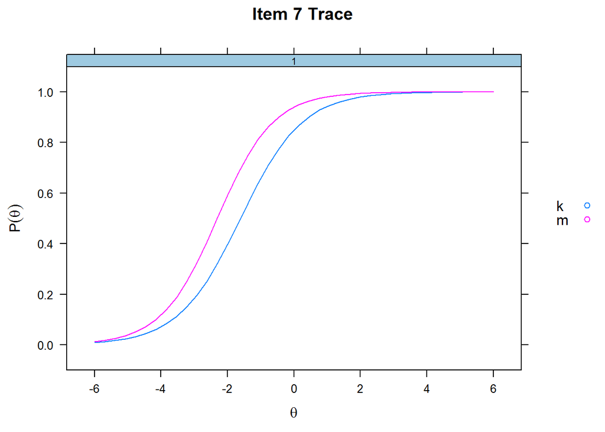

```r
> itemplot(mg_configural, item = 7)
```

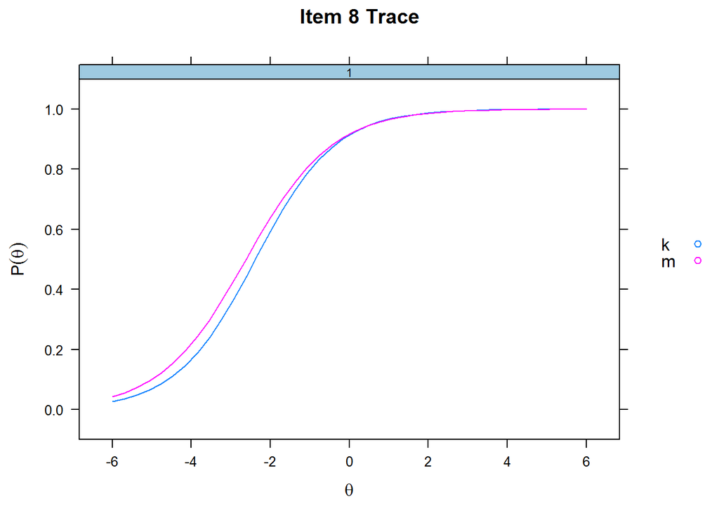

```r
> itemplot(mg_configural, item = 8)
```

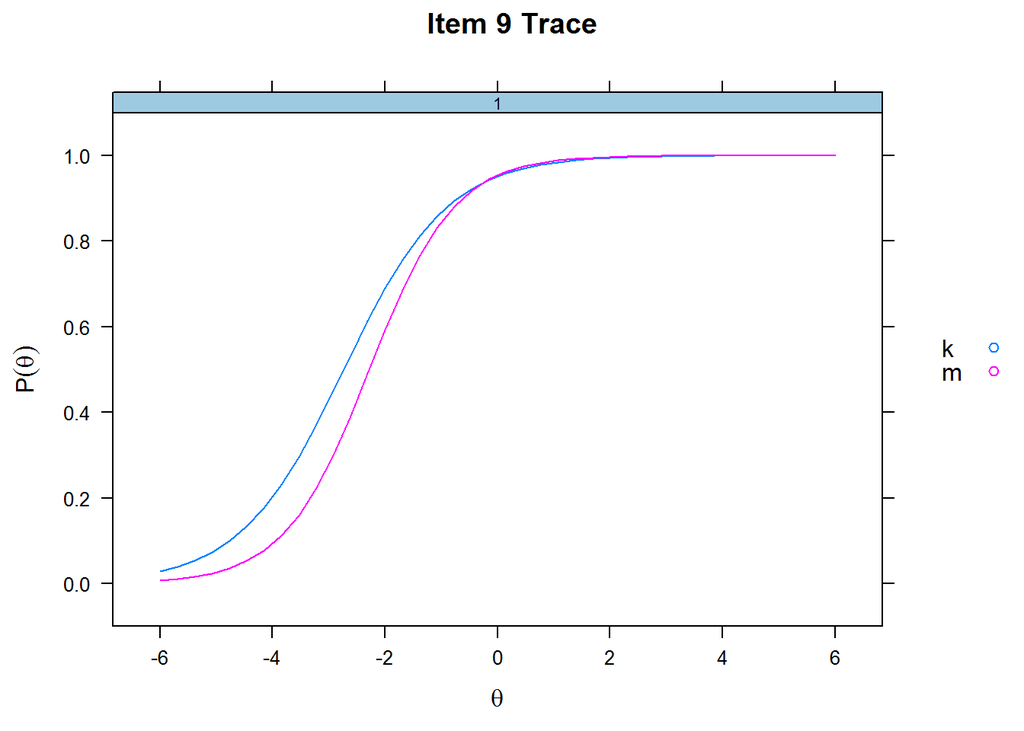

```r
> itemplot(mg_configural, item = 9)
```

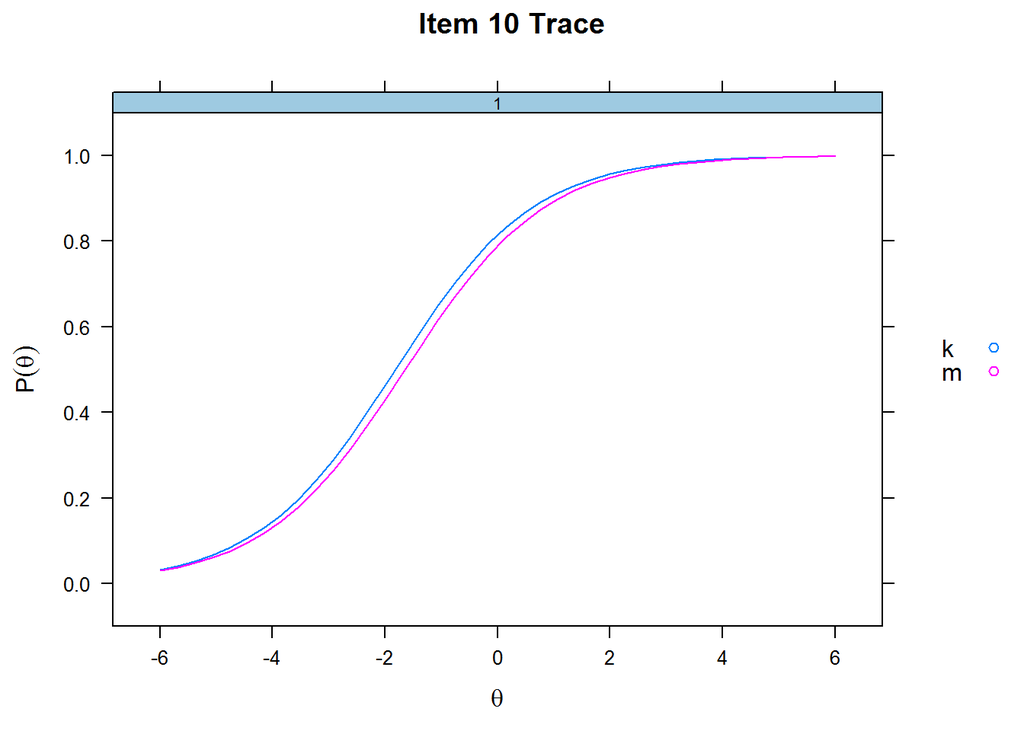

```r
> itemplot(mg_configural, item = 10)
```

# 5. Formalny test DIF

Przejdźmy w końcu do testowania DIF - wiemy, że nie mamy zachowanej niezmienniczości metrycznej, spójrzmy jak wygląda to na poziomie poszczególnych zadań. Funkcja ‘DIF’ wychodzi od modelu bez założonej inwariancji i kolejno testuje, jak na statystyki dopasowania modelu wpływa przyjęcie założenia, że dane zadanie ma takie same parametry w obu grupach (dopuszczając zróżnicowanie parametrów dla wszystkich innych zadań). Funkcja może też narysować wykresy krzywych charakterystycznych dla zadań, w których tak zdefiniowany DIF okazał się statystycznie istotny.

## Model z założonym takim samym rozkładem cechy w grupach

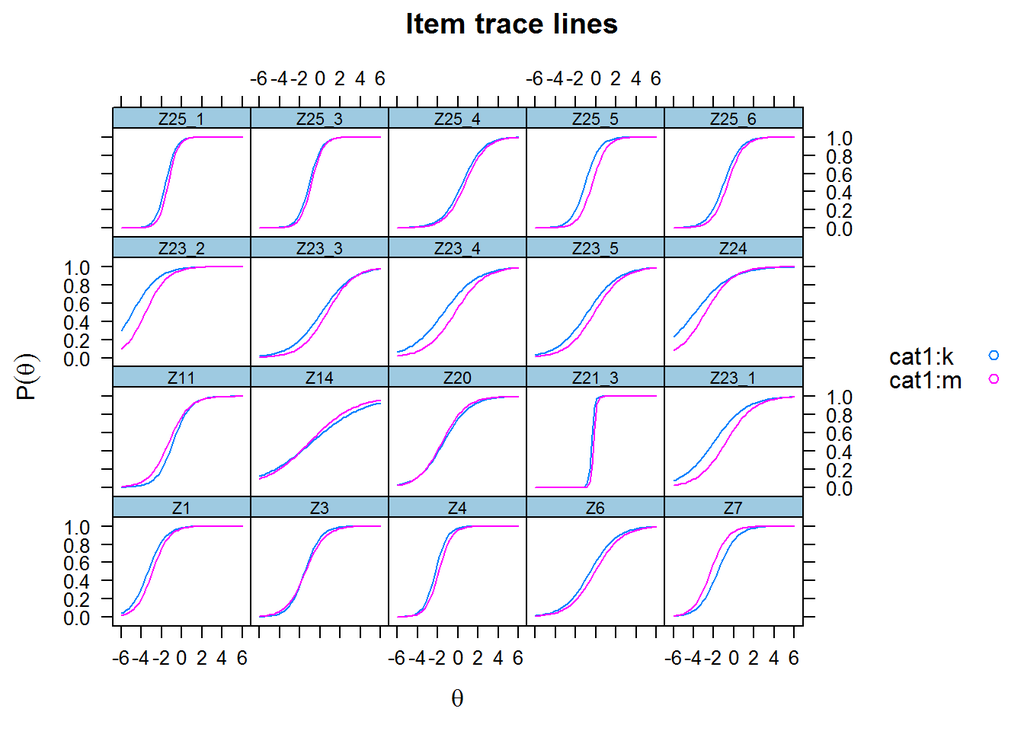

```r
> resulta1d = DIF(mg_configural, c('a1', 'd'), plotdif = TRUE)
No hyper-parameters were estimated in the DIF model. For effective
                    DIF testing, freeing the focal group hyper-parameters is recommended.
```

ĆWICZENIE 3: prosimy o interpretację różnic w prawdopodobieństwie uzyskania prawidłowej odpowiedzi w grupach chłopców i dziewcząt. Jakie są różnice we współczynnikach trudności i dyskryminacji

ĆWICZENIE 4: prosimy o zidentyfikowanie zadań wykazujących DIF przy pomocy arkusza egzaminacyjnego sprawdzianu 2005 (https://www.cke.edu.pl/images/stories/Sprawdzian2005/s-a1-052.pdf). Czy są Państwo w stanie postawić hipotezy na temat tego skąd może wynikać zróżnicowane funkcjonowanie zadań w grupach chłopców i dziewczynek?

## Model dopuszczający różnice w parametrach rozkładu cechy między grupami

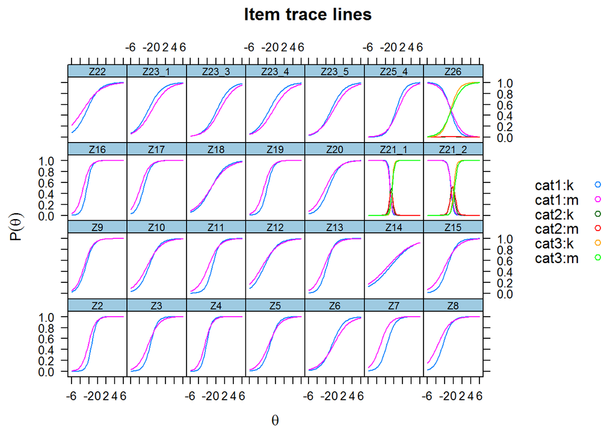

```r
> resulta2d = DIF(mg_configural_fg, c('a1', 'd'), plotdif = TRUE)
```

```r
###### opcjonalnie
# sprawdzamy czy za DIF odpowiedzialny jest wspolczynnik dyskryminacji
(a1s = DIF(mg_configural, 'a1', items2test = 1:37))
No hyper-parameters were estimated in the DIF model. For effective
                    DIF testing, freeing the focal group hyper-parameters is recommended.
Warning: Log-likelihood was decreasing near the ML solution. EM method may
be unstable
$Z1
       AIC     AICc    SABIC      BIC    logLik    X2  df      p
1 335264.3 335269.1 335881.3 336367.5 -167479.2   NaN NaN    NaN
2 335264.4 335269.3 335885.4 336374.8 -167478.2 1.882   1 0.1701

$Z2
       AIC     AICc    SABIC      BIC    logLik     X2  df   p
1 335260.8 335265.6 335877.8 336364.0 -167477.4    NaN NaN NaN
2 335264.4 335269.3 335885.4 336374.8 -167478.2 -1.604   1   1

$Z3
       AIC     AICc    SABIC      BIC    logLik    X2  df      p
1 335270.6 335275.4 335887.5 336373.8 -167482.3   NaN NaN    NaN
2 335264.4 335269.3 335885.4 336374.8 -167478.2 8.148   1 0.0043

$Z4
       AIC     AICc    SABIC      BIC    logLik     X2  df   p
1 335262.3 335267.0 335879.2 336365.4 -167478.1    NaN NaN NaN
2 335264.4 335269.3 335885.4 336374.8 -167478.2 -0.162   1   1

$Z5
       AIC     AICc    SABIC      BIC    logLik     X2  df   p
1 335258.3 335263.1 335875.3 336361.5 -167476.1    NaN NaN NaN
2 335264.4 335269.3 335885.4 336374.8 -167478.2 -4.133   1   1

$Z6
       AIC     AICc    SABIC      BIC    logLik    X2  df      p
1 335262.4 335267.2 335879.4 336365.6 -167478.2   NaN NaN    NaN
2 335264.4 335269.3 335885.4 336374.8 -167478.2 0.019   1 0.8904

$Z7
       AIC     AICc    SABIC      BIC    logLik    X2  df      p
1 335263.0 335267.8 335880.0 336366.2 -167478.5   NaN NaN    NaN
2 335264.4 335269.3 335885.4 336374.8 -167478.2 0.579   1 0.4467

$Z8
       AIC     AICc    SABIC      BIC    logLik     X2  df   p
1 335260.5 335265.3 335877.5 336363.7 -167477.3    NaN NaN NaN
2 335264.4 335269.3 335885.4 336374.8 -167478.2 -1.878   1   1

$Z9
       AIC     AICc    SABIC      BIC    logLik    X2  df      p
1 335262.6 335267.4 335879.5 336365.8 -167478.3   NaN NaN    NaN
2 335264.4 335269.3 335885.4 336374.8 -167478.2 0.152   1 0.6966

$Z10
       AIC     AICc    SABIC      BIC    logLik    X2  df   p
1 335259.8 335264.6 335876.8 336363.0 -167476.9   NaN NaN NaN
2 335264.4 335269.3 335885.4 336374.8 -167478.2 -2.59   1   1

$Z11
       AIC     AICc    SABIC      BIC    logLik     X2  df      p
1 335272.8 335277.6 335889.8 336376.0 -167483.4    NaN NaN    NaN
2 335264.4 335269.3 335885.4 336374.8 -167478.2 10.378   1 0.0013

$Z12
       AIC     AICc    SABIC      BIC    logLik     X2  df   p
1 335261.6 335266.3 335878.5 336364.7 -167477.8    NaN NaN NaN
2 335264.4 335269.3 335885.4 336374.8 -167478.2 -0.864   1   1

$Z13
       AIC     AICc    SABIC      BIC    logLik    X2  df      p
1 335264.7 335269.5 335881.7 336367.9 -167479.3   NaN NaN    NaN
2 335264.4 335269.3 335885.4 336374.8 -167478.2 2.274   1 0.1316

$Z14
       AIC     AICc    SABIC      BIC    logLik   X2  df     p
1 335265.3 335270.1 335882.3 336368.5 -167479.7  NaN NaN   NaN
2 335264.4 335269.3 335885.4 336374.8 -167478.2 2.91   1 0.088

$Z15
       AIC     AICc    SABIC      BIC    logLik    X2  df      p
1 335264.1 335268.9 335881.1 336367.3 -167479.1   NaN NaN    NaN
2 335264.4 335269.3 335885.4 336374.8 -167478.2 1.685   1 0.1943

$Z16
       AIC     AICc    SABIC      BIC    logLik    X2  df      p
1 335263.0 335267.7 335879.9 336366.1 -167478.5   NaN NaN    NaN
2 335264.4 335269.3 335885.4 336374.8 -167478.2 0.534   1 0.4649

$Z17
       AIC     AICc    SABIC      BIC    logLik    X2  df      p
1 335263.4 335268.2 335880.4 336366.6 -167478.7   NaN NaN    NaN
2 335264.4 335269.3 335885.4 336374.8 -167478.2 0.991   1 0.3195

$Z18
       AIC     AICc    SABIC      BIC    logLik    X2  df      p
1 335263.7 335268.5 335880.7 336366.9 -167478.9   NaN NaN    NaN
2 335264.4 335269.3 335885.4 336374.8 -167478.2 1.313   1 0.2519

$Z19
       AIC     AICc    SABIC      BIC    logLik    X2  df      p
1 335265.8 335270.6 335882.8 336369.0 -167479.9   NaN NaN    NaN
2 335264.4 335269.3 335885.4 336374.8 -167478.2 3.383   1 0.0659

$Z20
       AIC     AICc    SABIC      BIC    logLik     X2  df   p
1 335261.7 335266.4 335878.6 336364.8 -167477.8    NaN NaN NaN
2 335264.4 335269.3 335885.4 336374.8 -167478.2 -0.768   1   1

$Z21_1
       AIC     AICc    SABIC      BIC    logLik     X2  df   p
1 335261.1 335265.9 335878.1 336364.3 -167477.6    NaN NaN NaN
2 335264.4 335269.3 335885.4 336374.8 -167478.2 -1.324   1   1

$Z21_2
       AIC     AICc    SABIC      BIC    logLik     X2  df   p
1 335259.1 335263.9 335876.0 336362.3 -167476.5    NaN NaN NaN
2 335264.4 335269.3 335885.4 336374.8 -167478.2 -3.351   1   1

$Z21_3
       AIC     AICc    SABIC      BIC    logLik     X2  df   p
1 335256.4 335261.1 335873.3 336359.5 -167475.2    NaN NaN NaN
2 335264.4 335269.3 335885.4 336374.8 -167478.2 -6.068   1   1

$Z22
       AIC     AICc    SABIC      BIC    logLik    X2  df      p
1 335262.5 335267.3 335879.5 336365.7 -167478.3   NaN NaN    NaN
2 335264.4 335269.3 335885.4 336374.8 -167478.2 0.079   1 0.7787

$Z23_1
       AIC     AICc    SABIC      BIC    logLik    X2  df      p
1 335263.1 335267.9 335880.0 336366.3 -167478.5   NaN NaN    NaN
2 335264.4 335269.3 335885.4 336374.8 -167478.2 0.652   1 0.4194

$Z23_2
       AIC     AICc    SABIC      BIC    logLik    X2  df      p
1 335262.9 335267.7 335879.9 336366.1 -167478.5   NaN NaN    NaN
2 335264.4 335269.3 335885.4 336374.8 -167478.2 0.503   1 0.4782

$Z23_3
       AIC     AICc    SABIC      BIC    logLik    X2  df      p
1 335263.1 335267.9 335880.1 336366.3 -167478.6   NaN NaN    NaN
2 335264.4 335269.3 335885.4 336374.8 -167478.2 0.717   1 0.3971

$Z23_4
       AIC     AICc    SABIC      BIC    logLik    X2  df      p
1 335266.3 335271.1 335883.2 336369.5 -167480.1   NaN NaN    NaN
2 335264.4 335269.3 335885.4 336374.8 -167478.2 3.852   1 0.0497

$Z23_5
       AIC     AICc    SABIC      BIC    logLik     X2  df   p
1 335261.9 335266.7 335878.8 336365.1 -167477.9    NaN NaN NaN
2 335264.4 335269.3 335885.4 336374.8 -167478.2 -0.553   1   1
```

```r
$Z24
       AIC     AICc    SABIC      BIC    logLik    X2  df      p
1 335270.0 335274.8 335887.0 336373.2 -167482.0   NaN NaN    NaN
2 335264.4 335269.3 335885.4 336374.8 -167478.2 7.613   1 0.0058

$Z25_1
       AIC     AICc    SABIC      BIC    logLik    X2  df      p
1 335266.0 335270.8 335883.0 336369.2 -167480.0   NaN NaN    NaN
2 335264.4 335269.3 335885.4 336374.8 -167478.2 3.589   1 0.0582

$Z25_2
       AIC     AICc    SABIC      BIC    logLik     X2  df   p
1 335260.2 335265.0 335877.2 336363.4 -167477.1    NaN NaN NaN
2 335264.4 335269.3 335885.4 336374.8 -167478.2 -2.228   1   1

$Z25_3
       AIC     AICc    SABIC      BIC    logLik    X2  df      p
1 335263.8 335268.6 335880.8 336367.0 -167478.9   NaN NaN    NaN
2 335264.4 335269.3 335885.4 336374.8 -167478.2 1.358   1 0.2439

$Z25_4
       AIC     AICc    SABIC      BIC    logLik    X2  df      p
1 335264.0 335268.8 335880.9 336367.2 -167479.0   NaN NaN    NaN
2 335264.4 335269.3 335885.4 336374.8 -167478.2 1.546   1 0.2137

$Z25_5
       AIC     AICc    SABIC      BIC    logLik    X2  df      p
1 335264.8 335269.6 335881.8 336368.0 -167479.4   NaN NaN    NaN
2 335264.4 335269.3 335885.4 336374.8 -167478.2 2.383   1 0.1227

$Z25_6
       AIC     AICc    SABIC      BIC    logLik     X2  df   p
1 335262.3 335267.1 335879.3 336365.5 -167478.2    NaN NaN NaN
2 335264.4 335269.3 335885.4 336374.8 -167478.2 -0.082   1   1

$Z26
       AIC     AICc    SABIC      BIC    logLik     X2  df   p
1 335260.4 335265.2 335877.4 336363.6 -167477.2    NaN NaN NaN
2 335264.4 335269.3 335885.4 336374.8 -167478.2 -2.013   1   1
# lub wspolczynik trudnosci (dla zadan punktowanych zero-jedynkowo)
(ds = DIF(mg_configural, 'd', items2test = 1:20))
No hyper-parameters were estimated in the DIF model. For effective
                    DIF testing, freeing the focal group hyper-parameters is recommended.
Warning: Log-likelihood was decreasing near the ML solution. EM method may
be unstable

Warning: Log-likelihood was decreasing near the ML solution. EM method may
be unstable
$Z1
       AIC     AICc    SABIC      BIC    logLik   X2  df      p
1 335266.2 335271.0 335883.2 336369.4 -167480.1  NaN NaN    NaN
2 335264.4 335269.3 335885.4 336374.8 -167478.2 3.81   1 0.0509

$Z2
       AIC     AICc    SABIC      BIC    logLik    X2  df      p
1 335265.9 335270.7 335882.8 336369.1 -167479.9   NaN NaN    NaN
2 335264.4 335269.3 335885.4 336374.8 -167478.2 3.446   1 0.0634

$Z3
       AIC     AICc    SABIC      BIC    logLik     X2  df   p
1 335294.3 335299.1 335911.2 336397.5 -167494.1    NaN NaN NaN
2 335264.4 335269.3 335885.4 336374.8 -167478.2 31.849   1   0

$Z4
       AIC     AICc    SABIC      BIC    logLik     X2  df   p
1 335289.9 335294.7 335906.8 336393.0 -167491.9    NaN NaN NaN
2 335264.4 335269.3 335885.4 336374.8 -167478.2 27.439   1   0

$Z5
       AIC     AICc    SABIC      BIC    logLik     X2  df      p
1 335272.6 335277.4 335889.6 336375.8 -167483.3    NaN NaN    NaN
2 335264.4 335269.3 335885.4 336374.8 -167478.2 10.154   1 0.0014

$Z6
       AIC     AICc    SABIC      BIC    logLik     X2  df   p
1 335329.9 335334.7 335946.9 336433.1 -167512.0    NaN NaN NaN
2 335264.4 335269.3 335885.4 336374.8 -167478.2 67.488   1   0

$Z7
       AIC     AICc    SABIC      BIC    logLik      X2  df   p
1 335411.9 335416.7 336028.9 336515.1 -167553.0     NaN NaN NaN
2 335264.4 335269.3 335885.4 336374.8 -167478.2 149.514   1   0

$Z8
       AIC     AICc    SABIC      BIC    logLik    X2  df      p
1 335264.8 335269.6 335881.8 336368.0 -167479.4   NaN NaN    NaN
2 335264.4 335269.3 335885.4 336374.8 -167478.2 2.422   1 0.1196

$Z9
       AIC     AICc    SABIC      BIC    logLik   X2  df      p
1 335262.6 335267.4 335879.6 336365.8 -167478.3  NaN NaN    NaN
2 335264.4 335269.3 335885.4 336374.8 -167478.2 0.19   1 0.6629

$Z10
       AIC     AICc    SABIC      BIC    logLik    X2  df      p
1 335266.6 335271.4 335883.5 336369.8 -167480.3   NaN NaN    NaN
2 335264.4 335269.3 335885.4 336374.8 -167478.2 4.153   1 0.0416

$Z11
       AIC     AICc    SABIC      BIC    logLik     X2  df   p
1 335279.4 335284.2 335896.4 336382.6 -167486.7    NaN NaN NaN
2 335264.4 335269.3 335885.4 336374.8 -167478.2 16.969   1   0

$Z12
       AIC     AICc    SABIC      BIC    logLik    X2  df      p
1 335265.4 335270.1 335882.3 336368.5 -167479.7   NaN NaN    NaN
2 335264.4 335269.3 335885.4 336374.8 -167478.2 2.928   1 0.0871

$Z13
       AIC     AICc    SABIC      BIC    logLik     X2  df     p
1 335273.2 335278.0 335890.2 336376.4 -167483.6    NaN NaN   NaN
2 335264.4 335269.3 335885.4 336374.8 -167478.2 10.766   1 0.001

$Z14
       AIC     AICc    SABIC      BIC    logLik     X2  df     p
1 335276.5 335281.3 335893.5 336379.7 -167485.3    NaN NaN   NaN
2 335264.4 335269.3 335885.4 336374.8 -167478.2 14.116   1 2e-04

$Z15
       AIC     AICc    SABIC      BIC    logLik    X2  df      p
1 335266.5 335271.3 335883.5 336369.7 -167480.2   NaN NaN    NaN
2 335264.4 335269.3 335885.4 336374.8 -167478.2 4.065   1 0.0438

$Z16
       AIC     AICc    SABIC      BIC    logLik     X2  df   p
1 335262.0 335266.8 335879.0 336365.2 -167478.0    NaN NaN NaN
2 335264.4 335269.3 335885.4 336374.8 -167478.2 -0.413   1   1

$Z17
       AIC     AICc    SABIC      BIC    logLik    X2  df      p
1 335264.4 335269.2 335881.4 336367.6 -167479.2   NaN NaN    NaN
2 335264.4 335269.3 335885.4 336374.8 -167478.2 1.998   1 0.1575

$Z18
       AIC     AICc    SABIC      BIC    logLik    X2  df      p
1 335270.6 335275.4 335887.6 336373.8 -167482.3   NaN NaN    NaN
2 335264.4 335269.3 335885.4 336374.8 -167478.2 8.156   1 0.0043

$Z19
       AIC     AICc    SABIC      BIC    logLik    X2  df      p
1 335263.0 335267.7 335879.9 336366.1 -167478.5   NaN NaN    NaN
2 335264.4 335269.3 335885.4 336374.8 -167478.2 0.537   1 0.4637

$Z20
       AIC     AICc    SABIC      BIC    logLik     X2  df     p
1 335275.0 335279.7 335891.9 336378.1 -167484.5    NaN NaN   NaN
2 335264.4 335269.3 335885.4 336374.8 -167478.2 12.527   1 4e-04
(ds = DIF(mg_configural, 'd', items2test = 23:36))
No hyper-parameters were estimated in the DIF model. For effective
                    DIF testing, freeing the focal group hyper-parameters is recommended.
$Z21_3
       AIC     AICc    SABIC      BIC    logLik    X2  df      p
1 335267.9 335272.7 335884.9 336371.1 -167481.0   NaN NaN    NaN
2 335264.4 335269.3 335885.4 336374.8 -167478.2 5.508   1 0.0189
```

```r
$Z22
       AIC     AICc    SABIC      BIC    logLik    X2  df      p
1 335263.9 335268.6 335880.8 336367.0 -167478.9   NaN NaN    NaN
2 335264.4 335269.3 335885.4 336374.8 -167478.2 1.429   1 0.2319

$Z23_1
       AIC     AICc    SABIC      BIC    logLik      X2  df   p
1 335451.6 335456.4 336068.6 336554.8 -167572.8     NaN NaN NaN
2 335264.4 335269.3 335885.4 336374.8 -167478.2 189.186   1   0

$Z23_2
       AIC     AICc    SABIC      BIC    logLik    X2  df      p
1 335272.0 335276.8 335889.0 336375.2 -167483.0   NaN NaN    NaN
2 335264.4 335269.3 335885.4 336374.8 -167478.2 9.604   1 0.0019

$Z23_3
       AIC     AICc    SABIC      BIC    logLik     X2  df   p
1 335358.9 335363.7 335975.9 336462.1 -167526.5    NaN NaN NaN
2 335264.4 335269.3 335885.4 336374.8 -167478.2 96.479   1   0

$Z23_4
       AIC     AICc    SABIC      BIC    logLik      X2  df   p
1 335465.1 335469.9 336082.1 336568.3 -167579.5     NaN NaN NaN
2 335264.4 335269.3 335885.4 336374.8 -167478.2 202.666   1   0

$Z23_5
       AIC     AICc    SABIC      BIC    logLik     X2  df   p
1 335361.3 335366.1 335978.3 336464.5 -167527.7    NaN NaN NaN
2 335264.4 335269.3 335885.4 336374.8 -167478.2 98.882   1   0

$Z24
       AIC     AICc    SABIC      BIC    logLik    X2  df   p
1 335259.7 335264.5 335876.7 336362.9 -167476.9   NaN NaN NaN
2 335264.4 335269.3 335885.4 336374.8 -167478.2 -2.68   1   1

$Z25_1
       AIC     AICc    SABIC      BIC    logLik    X2  df      p
1 335269.5 335274.3 335886.5 336372.7 -167481.8   NaN NaN    NaN
2 335264.4 335269.3 335885.4 336374.8 -167478.2 7.109   1 0.0077

$Z25_2
       AIC     AICc    SABIC      BIC    logLik    X2  df   p
1 335258.7 335263.5 335875.7 336361.9 -167476.4   NaN NaN NaN
2 335264.4 335269.3 335885.4 336374.8 -167478.2 -3.69   1   1

$Z25_3
       AIC     AICc    SABIC      BIC    logLik    X2  df      p
1 335268.4 335273.2 335885.4 336371.6 -167481.2   NaN NaN    NaN
2 335264.4 335269.3 335885.4 336374.8 -167478.2 5.957   1 0.0147

$Z25_4
       AIC     AICc    SABIC      BIC    logLik     X2  df   p
1 335299.2 335304.0 335916.1 336402.4 -167496.6    NaN NaN NaN
2 335264.4 335269.3 335885.4 336374.8 -167478.2 36.753   1   0

$Z25_5
       AIC     AICc    SABIC      BIC    logLik      X2  df   p
1 335510.7 335515.4 336127.6 336613.8 -167602.3     NaN NaN NaN
2 335264.4 335269.3 335885.4 336374.8 -167478.2 248.238   1   0

$Z25_6
       AIC     AICc    SABIC      BIC    logLik     X2  df   p
1 335312.5 335317.3 335929.5 336415.7 -167503.2    NaN NaN NaN
2 335264.4 335269.3 335885.4 336374.8 -167478.2 50.071   1   0
```

# 6. Wielkość efektu DIF

Jak już zostało wcześniej wspomniane - dla dużych zbiorów danych jakimi są egzaminy, wykrycie DIF technikami opierającymi się o istność statystyczną może być mylące (na dużych zbiorach danych wszystko wychodzi istotne statystycznie. Dlatego też w analizach DIF warto zwrócić uwagę na bardziej praktyczną miarę - czy efekt ten choć istotny statystycznie jest duży czy mały.

W pakiecie ‘mirt’ domyślnie zaimplementowane sa inne miary wielkości efektu, z funkcji liczącej IRT P-DIF korzystamy dzięki uprzejmości Tomka Żółtaka.

Dla przypomnienia klasyfikacja miar wielkości efektu: Miary wielkości efektu DIF wyrażone są na skali łatwości zadania (Monahan i in., 2007): • Kategoria A– gdy test weryfikujący statystyczną istotność DIF dał wynik negatywny, lub gdy wynik testu jest pozytywny, ale absolutna wartość P-DIF jest mniejsza od 0,05; • Kategoria B – gdy DIF jest statystycznie istotne oraz absolutna wartość P-DIF znajduje się w przedziale od 0,05 do 0,1; • Kategoria C – gdy DIF jest statystycznie istotne oraz absolutna wartość P-DIF wykracza poza przedział (0,1).

```r
>
> PDIF = function(x, grOgniskowa, emp = TRUE) {
+   stopifnot("MultipleGroupClass" %in% class(x),
+             is.vector(grOgniskowa), is.vector(emp))
+   stopifnot(x@Data$ngroups == 2,
+             is.character(grOgniskowa) | is.numeric(grOgniskowa),
+             length(grOgniskowa) == 1, length(emp) == 1,
+             all(emp) %in% c(TRUE, FALSE))
+   if (is.numeric(grOgniskowa)) {
+     stopifnot(grOgniskowa %in% 1:2)
+   } else {
+     stopifnot(grOgniskowa %in% x@Data$groupNames)
+     grOgniskowa = which(x@Data$groupNames == grOgniskowa)
+   }
+   grOdniesienia = setdiff(1:2, grOgniskowa)
+   if (emp) {
+     theta = fscores(x, "EAP")[as.numeric(x@Data$group) %in% grOgniskowa]
+   } else {
+     mCov = coef(x, simplify = TRUE)[[grOgniskowa]]$cov
+     mCov[upper.tri(mCov)] = t(mCov)[upper.tri(mCov)]
+     theta = rmvnorm(10^5, coef(x, simplify = TRUE)[[grOgniskowa]]$means, mCov)
+   }
+
+   pdif = as.numeric(rep(NA, x@Data$nitems))
+   for (i in 1:length(pdif)) {
+     pdif[i] = mean(expected.item(extract.item(x, i, grOgniskowa), theta)) -
+       mean(expected.item(extract.item(x, i, grOdniesienia), theta))
+   }
+   return(pdif)
+ }
>
> data.frame(zadanie = names(daneZapunktowane),
+            PDIF = round(PDIF(mg_configural, "m"), 2))
   zadanie  PDIF
1       Z1 -0.01
2       Z2  0.02
3       Z3 -0.04
4       Z4 -0.04
5       Z5 -0.03
6       Z6 -0.08
7       Z7  0.10
8       Z8  0.01
9       Z9 -0.01
10     Z10 -0.02
11     Z11  0.05
12     Z12 -0.02
13     Z13 -0.02
14     Z14  0.04
15     Z15 -0.01
16     Z16  0.00
17     Z17  0.00
18     Z18 -0.03
19     Z19  0.01
20     Z20  0.04
21   Z21_1 -0.14
22   Z21_2 -0.15
23   Z21_3 -0.07
24     Z22 -0.01
25   Z23_1 -0.13
26   Z23_2 -0.02
27   Z23_3 -0.10
28   Z23_4 -0.14
29   Z23_5 -0.10
30     Z24 -0.01
31   Z25_1 -0.03
32   Z25_2  0.00
33   Z25_3 -0.04
34   Z25_4 -0.06
35   Z25_5 -0.16
36   Z25_6 -0.08
37     Z26 -0.14
```

Ćwiczenie 5: Prosimy o zinterpretowanie wielkości efektów dla zadań zidentyfikowanych wcześniej jako posiadające DIF. Ile zadań można zaklasyfikować do kategorii A, B i C. Które to sa zadania?